# Contextualizing Ebola Frenzy

some Smith students

**ABSTRACT**

*The panic from the onset of an Ebola epidemic in West Africa has had reverberations worldwide, but especially in the American media. Does this apparent surge of media attention on Ebola reflect an unusual response to pandemic disease, or is this response expected based on the characteristics of the disease itself? This study sought to analyze media attention surrounding Ebola by comparing its associated media response, proxied by scaled interest from Google Trends, to an expected range of interest. Media attention was broken down into two timescales - the month of November 2014 and the past year - to clarify discrepancies between media response in the short and long term. To generate the expected range of interest, a multiple linear regression model was built to predict proxied media response as a function of common characteristics of pandemics. This model predicted that media response to Ebola did not fall outside of this expected range; however, shortcomings in data collection and violations of assumptions for inference from multiple linear regression render these results inconclusive.*

**INTRODUCTION**

Since the outbreak of Ebola in the summer of 2014, what was once an obscure disease has turned into media frenzy on the tips of everyone’s tongues. Suddenly panic was in the air as people made apocalyptic preparations. The public feared that a virus of which they had only recently become aware could leach into their water, into their air, invading their bodies and dissolving their organs into sludge. As the news reports catalogued the growing death tolls thousands of miles and an ocean away, hysteria spread on American soil. This is certainly neither the first nor the last time that pandemic disease will be accompanied by an equally contagious anxiety. So is the attention surrounding Ebola a normal response warranted by the characteristics of the disease itself, or does this trend in media response indicate a more extreme reaction?

In this observational study, we used the characteristics for 23 pandemic diseases to build a model predicting the media response to a disease as proxied by scaled data from Google Trends. We analyzed the media response to Ebola both in the short term (the month of November 2014) and in the long term (the previous year) to elucidate any trends or discrepancies determining media response over time.

**DATA**

The observational units of this study are pandemic diseases. These diseases represent a sample of all pandemic diseases, based on availability of data, and are not restricted to those in any particular area of the world. However, some of these diseases do not have global spread. The causes of these diseases are of either bacterial or viral nature. While the features that characterize diseases are complex, we limit our characterization to a few parameters based on the availability of data. The data was derived from various credible online sources, primarily from a project called Microbe-scope, the Center of Disease Control, the World Health Organization, and the National Center for Biotechnology Information.

```r
mydata <- read.table("StatsGroupProjectNewData.csv", header=TRUE, sep=",")
head(mydata, n=5)
```

```
##           Disease CaseFatality ReproductionNum YearlyFatal YearlyFatalUS
## 1 Bird Flu (H5N1)       0.6000            1.00          18             0
## 2         Cholera       0.0163            2.13       94000             0
## 3      Diphtheria       0.0750            6.50        5000             1
## 4          E.coli       0.0400            1.15      260000           100
## 5     Hepatitis B       0.0075            4.04      600000          3000
##   YearlyFatalAfrica Cure Prevent SearchNov SearchYear
## 1                 3    0       1         8         47
## 2             55000    1       0        28        440
## 3              1700    0       0        37       1797
## 4            103000    1       1        32        540
## 5             18600    1       0       168       2807
```

A portion of our data is shown above. Note that we do not include Ebola in this dataset since its inclusion would articifically improve the model’s fit to its parameters.

The case fatality rate is a percentage of the total cases for a disease which resulted in death.The average basic reproduction number ($R_0$) describes the contagiousness of the disease; it is the number of cases one case generates on average over the course of its infectious period, in an otherwise uninfected population. Thus a greater $R_0$ value implies greater potential for transmission. The yearly fatalities of each disease, the number of deaths, were found for three different populations pertinent to the analysis of Ebola: worldwide, in the United States, and in Africa. The availability of a cure or vaccine describes the accessible means to successfully treat and prevent a given disease. These treatments must not only have been developed, but also be approved by the FDA and available for distribution. Thus, a drug may have been developed for a certain virus, but if it is not available in the US, it was not considered for the purposes of this study. Both of these are categorical variables, which take binary values 0 (cure or vaccine is available) or 1 (cure or vaccine is not available). This distinction is based on the assumption that the unavailability of a vaccine or cure would cause greater media attention.

The media response to each disease was proxied by interest as calculated by Google Trends. These values are set to a scale ranging from zero to one-hundred, with zero being the least interest and one-hundred being the most. For the short term data, we summed Google Trends ouputs from November 1 to November 23, 2014. For the long term data, we summed Google Trends outputs from November 23, 2013 to November 23, 2014. Note that Google Trends operates such that week-long intervals are the units of time that are assigned values between zero and one-hundred; therefore it is possible for these values in our dataset to be over one-hundred. For Ebola, the short term media response is 37 and the long term media response is 528.

**RESULTS**

Using best subsets regression, we determined the best set of explanatory variables to model the short and long term media responses proxied by Google Trends.

```r
require(leaps)
#Find all adjusted R squared values for all possible combinations of variables for the short term model
best_subset_short <- leaps(x = mydata[,2:8], y = mydata[,9], names = names(mydata)[2:8], method = "adjr2")
#Find the best model of this set based on highest adjusted R squared
best.short.adjr2 = best_subset_short$which[which((best_subset_short$adjr2 == max(best_subset_short$adjr2))),]
best.short.adjr2
```

```
##      CaseFatality   ReproductionNum       YearlyFatal     YearlyFatalUS
##             FALSE              TRUE             FALSE             FALSE
## YearlyFatalAfrica              Cure           Prevent
##              TRUE              TRUE              TRUE
```

```r
m_short<-lm(SearchNov~ReproductionNum+YearlyFatalUS+Prevent, data=mydata)
summary(m_short)
```

```
##
## Call:
## lm(formula = SearchNov ~ ReproductionNum + YearlyFatalUS + Prevent,
##     data = mydata)
##
## Residuals:
##    Min     1Q Median     3Q    Max
## -56.92 -15.83  -9.96  22.52  71.68
##
## Coefficients:
##                  Estimate Std. Error t value Pr(>|t|)
## (Intercept)      82.72811   12.55434    6.59  2.6e-06 ***
## ReproductionNum   1.02914    0.47991    2.14   0.0451 *
## YearlyFatalUS     0.00855    0.00243    3.53   0.0023 **
## Prevent         -41.46266   16.19340   -2.56   0.0191 *
## ---
## Signif. codes:  0 '***' 0.001 '**' 0.01 '*' 0.05 '.' 0.1 ' ' 1
##
## Residual standard error: 36.4 on 19 degrees of freedom
## Multiple R-squared:  0.479,  Adjusted R-squared:  0.397
## F-statistic: 5.83 on 3 and 19 DF,  p-value: 0.00535
```

```r
#Find all adjusted R squared values for all possible combinations of variables for the long term model
best_subset_long <- leaps(x = mydata[,2:8], y = mydata[,10], names = names(mydata)[2:8], method = "adjr2")
#Find the best model of this set based on highest adjusted R squared
best.long.adjr2 = best_subset_long$which[which((best_subset_long$adjr2 == max(best_subset_long$adjr2))),]
best.long.adjr2
```

```
##      CaseFatality   ReproductionNum       YearlyFatal     YearlyFatalUS
##             FALSE              TRUE             FALSE              TRUE
## YearlyFatalAfrica              Cure           Prevent
##             FALSE             FALSE              TRUE
```

In the long term, the explanatory variables were reproduction number, the number of yearly fatalities in the United States, and whether or not there are means of prevention.

```r
m_long<-lm(SearchYear~YearlyFatalUS+Prevent+ReproductionNum, data=mydata)
summary(m_long)
```

```
##
## Call:
## lm(formula = SearchYear ~ YearlyFatalUS + Prevent + ReproductionNum,
##     data = mydata)
##
## Residuals:
##     Min      1Q  Median      3Q     Max
## -1231.3  -305.6    22.3   286.7   980.2
##
## Coefficients:
##                  Estimate Std. Error t value Pr(>|t|)
## (Intercept)     1644.1188   192.1870    8.55  6.1e-08 ***
## YearlyFatalUS      0.1388     0.0371    3.74  0.00139 **
## Prevent         -987.8358   247.8952   -3.98  0.00079 ***
## ReproductionNum   12.7611     7.3467    1.74  0.09857 .
## ---
## Signif. codes:  0 '***' 0.001 '**' 0.01 '*' 0.05 '.' 0.1 ' ' 1
##
## Residual standard error: 557 on 19 degrees of freedom
## Multiple R-squared:  0.563,  Adjusted R-squared:  0.494
## F-statistic: 8.15 on 3 and 19 DF,  p-value: 0.00109
```

Prevention was included in both models and was associated with a decrease in media response in both. Note that the sign of this variable is unexpected. One might expect that the lack of a vaccine (corresponding to 1 in the model) would increase media attention; however, we see the opposite. This variable itself is strange; it should be noted, for example, that only diseases which have a viral source can be vaccinated against. This excludes several cases in our data that are bacterial. For those diseases which are viral in nature, those which have a vaccine are potentially more likely to be well known and studied. This is a consequence of the fact that a disease would have to have been a significant enough concern at some point in the past to warrant the effort and funding to produce a vaccine. The remaining variables characteristic of pandemic diseases in our dataset were assessed for their use in these models, but were not found to be valuable, both in terms of their p-values and their contribution to adjusted $R^2$.

Prior to moving forward with inference, we checked assumptions for these models including normality, linearity,independence of residuals and constant variance.

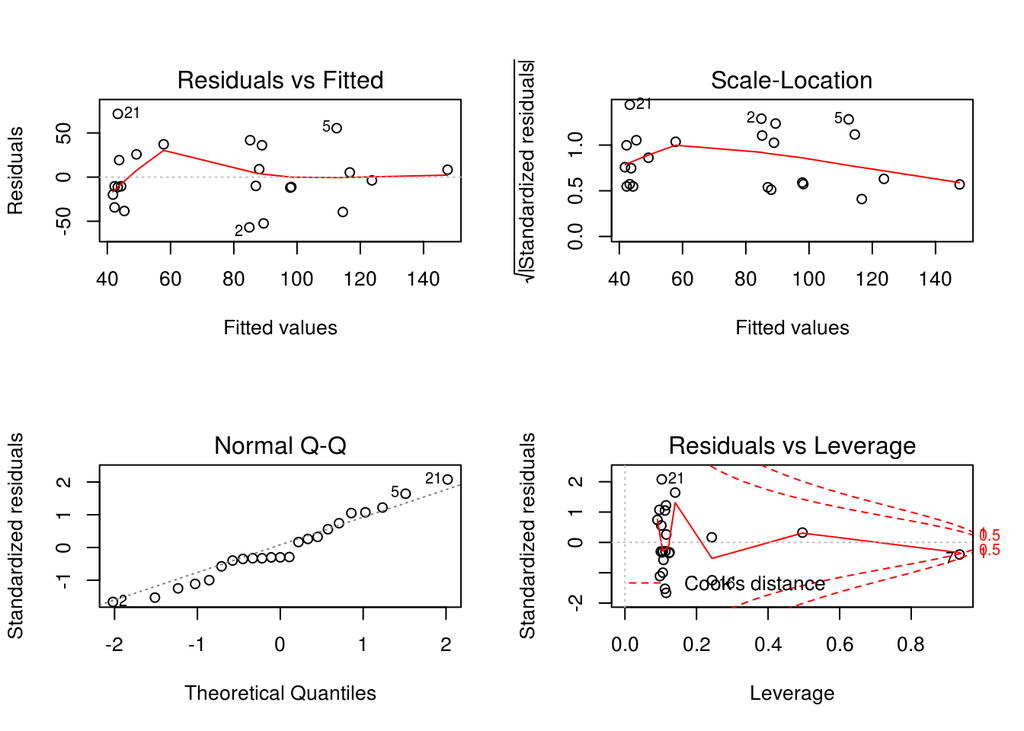

```r
layout(matrix(c(1, 2, 3, 4),2,2))
plot(m_short) #Diagnostics for the short term model
```

For the short term model, from the Residuals vs. Fitted Values plot we see that the distribution of the residuals on either side of this line is fairly equal, but it is difficult to discern constant variance because of the low number of points. Furthermore it is not apparent that the residuals are distributed randomly around zero, which undermines linearity. From the Normal Q-Q plot, the residuals appear to oscillate in a manner that undermines normality. From the Residuals vs. Leverage plot, we see that there are no influential points.

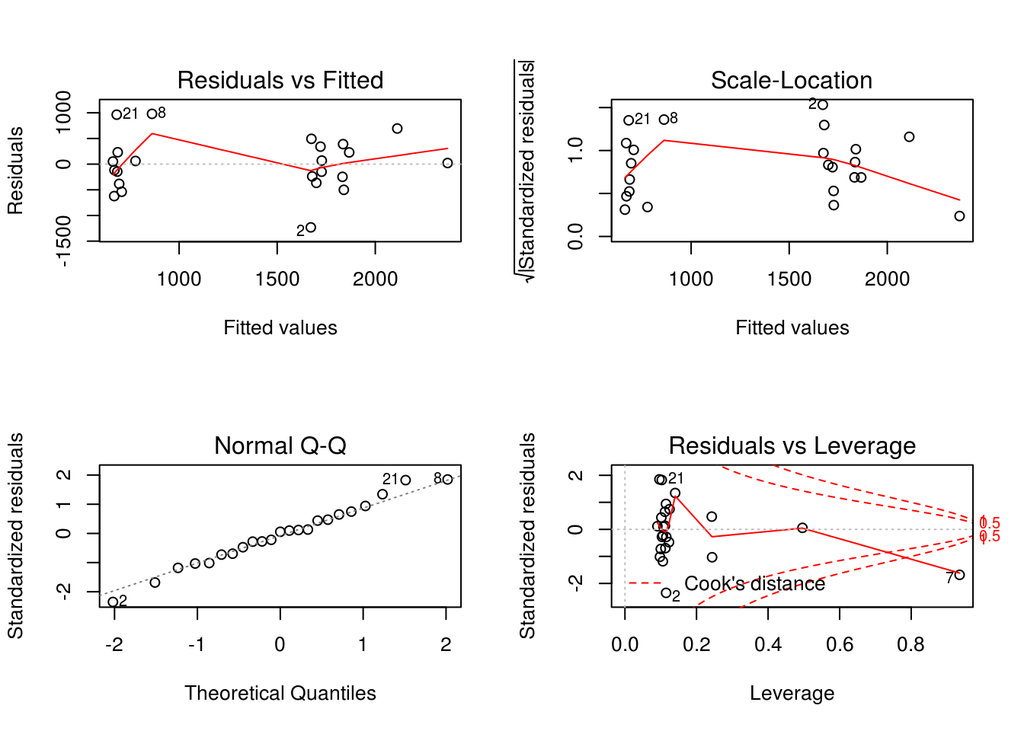

```r
layout(matrix(c(1, 2, 3, 4),2,2))
plot(m_long) #Diagnostics for the long term model
```

Returning to the question under study, we examined the extremity of the media response to Ebola using a 95% predictor interval to determine a reasonable range for media response.

```r
#Predictor interval for the short term model
#attach(mydata)
m_short<-lm(SearchNov~ReproductionNum+YearlyFatalUS+Prevent, data=mydata)
#Input the values of these parameters for Ebola
new.short.data = data.frame(ReproductionNum=2.5, YearlyFatalUS=1, Prevent=1)
#Find a 95% predictor interval, given these parameters
predict(m_short, new.short.data, interval="predict")
```

```
##     fit    lwr   upr
## 1 43.85 -36.11 123.8
```

```r
#Predictor interval for long term model
m_long<-lm(SearchYear~YearlyFatalUS+Prevent+ReproductionNum, data=mydata)
#Input the values of these parameters for Ebola
new.long.data = data.frame(YearlyFatalUS = 1, Prevent = 1, ReproductionNum=2.5)
#Find a 95% predictor interval
predict(m_long, new.long.data, interval="predict")
```

```
##     fit    lwr  upr
## 1 688.3 -535.6 1912
```

**CONCLUSION**

Our models suggest that, in the short term, media attention derives from the number of yearly fatalities in the United States, reproduction number, and availability of a vaccine. In the long term, case fatalities in the United States, reproduction number, and prevention predict media attention. From this, we conjecture that the variables which influence media attention in the short term are the same as those in the long term. The availability of a vaccine was present in both models, suggesting that the influence of the ability to prevent initial contraction of a disease is important both in the short and long term. The presence of reproduction number suggests that the contagiousness of a disease is also important regardless of the timescale. These similarities between the two models imply that, whether in the short or long term, concern about infectious diseases centers on contagiousness and potential for fatalities on American soil, regardless of the pandemic epicenter.

Unexpectedly, our analysis suggests that the media response to Ebola is not extreme in comparison to the response predicted by the model, both in the long and short term. The conclusiveness of these findings, however, is severely in question due to a number of flaws. These begin with the data collection process. The limited nature of epidemiological data made it difficult to find sufficient and precise values; for example, case fatality rates are often given as ranges and can differ vastly depending on the geographic location of the outbreak or the infected demographic. However, we were forced to restrict these ranges to single discrete values for the modeling process. Furthermore, the independence of each case is called into question due to comorbidity between diseases (e.g. the contraction of tuberculosis is strongly correlated with the incidence of HIV). Numeric rounding was inherent in our data collection process because of inconsistencies in estimates among multiple sources. The difficulty of finding data resulted in a very small number of cases, insufficiently large enough to compensate for any abnormality in the cases. Abnormality observed in the residuals likely stems from flaws in the data set itself. Were we able to collect data through more accurate and consistent means for a larger number of diseases, perhaps the assumptions necessary for inference for multiple linear regression could have held. The inability of the data to meet these assumptions fully renders our results inconclusive.

**REFERENCES**

“The ABCs of Hepatitis.” Centers for Disease Control and Prevention. August 2012. Accessed November 2014. http://www.cdc.gov/hepatitis/Resources/Professionals/PDFs/ABCTable.pdf.

“Cryptococcal Meningitis: A Deadly Fungal Disease among People Living with HIV&/AIDS.” Centers for Disease Control and Prevention. Accessed November 2014. http://www.cdc.gov/fungal/pdf/at-a-glance-508c.pdf.

“Disease Burden from Viral Hepatitis A, B, and C in the United States.” Centers for Disease Control and Prevention. Accessed November 2014. http://www.cdc.gov/hepatitis/PDFs/disease_burden.pdf.

“E. coli (Escherichia coli): General Information.” Centers for Disease Control and Prevention. August 2012. Accessed November 2014. http://www.cdc.gov/ecoli/general/index.html.

Fielder, J. F., C. P. Chaulk, M. Dalvi, R. Gachuhi, G. W. Comstock, and T. R. Sterling. “A High Tuberculosis Case-Fatality Rate in a Setting of Effective Tuberculosis Control: Implications for Acceptable Treatment Success Rates.” International Journal of Tuberculosis and Lung Disease 6.12 (2002): 1114–1117. Accessed November 2014. http://www.ncbi.nlm.nih.gov/pubmed/12546121.

Gish, Robert. “What is Hepatitis E?” National Virus Hepatitis Roundtable. 2014. http://nvhr.org/content/what-hepatitis-e. “Global Immunization: Disease and Vaccines – A World View.” Parent’s Pack, The Children’s Hospital of Philadelphia. February 2013. Accessed November 2014. http://vec.chop.edu/service/parents-possessing-accessing-communicating-knowledge-about-vaccines/global-immunization/diseases-and-vaccines-a-world-view.html.

Greenhalgh, D., and N. Sfikas. “A Statistical Method for Modelling Hepatitis A Vaccination in Bulgaria.” 2006. Accessed November 2014. http://www.wseas.us/e-library/conferences/2006cavtat/papers/527-115.pdf

“Hepatitis A: Surveillance and Control.” Global Alert and Response (GAR), World Health Organization. 2014. Accessed November 2014.  
http://www.who.int/csr/disease/hepatitis/whocdscsredc2007/en/index4.html.

“Hepatitis C.” Media Centre, World Health Organization. April 2014. Accessed November 2014. http://www.who.int/mediacentre/factsheets/fs164/en/ “Hepatitis C Statistics.” National Medical Association. Accessed November 2014. http://www.nmanet.org/index.php?option=com_content&view=article&id=291&Itemid=420.

“Hepatitis C: Surveillance and Control.” Global Alert and Response (GAR), World Health Organization. 2014. Accessed November 2014. http://w ww.who.int/csr/disease/hepatitis/whocdscsrlyo2003/en/index4.html. Iacono, Gianni L. “Estimating the Contribution of Human-to-Human Transmission to Lassa Fever.” Dynamic Drivers of Disease in Africa. 2014. Accessed November 2014. http://www.slideshare.net/Driversofdisease/gianni-lo-iaconolassa.

Inegbenebor, U., J. Okosun, and J. Inegbenebor. “Prevention of Lassa Fever in Nigeria.” Transactions of the Royal Society of Tropical Medicine and Hygiene 104.1 (2010): 51–54. Accessed November 2014. http://www.ncbi.nlm.nih.gov/pubmed/19712954.

Karoney, Mercy J., and Abraham M. Siika. “Hepatitis C Virus (HCV) Infection in Africa: A Review.” The Pan African Medical Journal. 14.44 (2013). Accessed November 2014. http://www.panafrican-med-journal.com/content/article/14/44/full/.

“Key Facts about Avian Influenza (Bird Flu) and Highly Pathogenic Avian Influenza A (H5N1) Virus.” Centers for Disease Control and Prevention. November 2010. Accessed November 2014. http://www.cdc.gov/flu/avian/gen-info/facts.htm.

Kim, Jong-Hoon, Kenrad E. Nelson, Ursula Panzner, Yogita Kasture, Alain B. Labrique, and Thomas F. Wierzba. “A Systematic Review of the Epidemiology of Hepatitis E Virus in Africa.” BMC Infectious Diseases. 14.308 (2014). Accessed November 2014. http://www.biomedcentral.com/1471-2334/14/308.

“Lassa Fever Fact Sheet.” Centers for Disease Control and Prevention. Accessed November 2014. http://www.cdc.gov/ncidod/dvrd/spb/mnpages/dispages/Fact_Sheets/Lassa_Fever_Fact_Sheet.pdf.

McCandless, David. “Microbe-Scope.” Information is Beautiful. October 2014. Accessed November 2014. http://bit.ly/KIB_Microbescope.

“Meningococcal Disease: Epidemiology and Prevention of Vaccine-Preventable Diseases.” Centers for Control and Prevention. 2012. Accessed November 2014. http://www.cdc.gov/vaccines/pubs/pinkbook/mening.html.

“Middle East Respiratory Syndrome (MERS): Prevention and Treatment.” Centers for Disease Control and Prevention. November 2014. Accessed November 2014. http://www.cdc.gov/coronavirus/MERS/about/prevention.html.

“Prevent the Spread of Norovirus.” Centers for Disease Control and Prevention. November 2014. Accessed November 2014. http://www.cdc.gov/features/norovirus/.

“Rift Valley Fever (RVF).” Centers for Disease Control and Prevention. November 2013. Accessed November 2014. http://www.cdc.gov/vhf/rvf/.

“Salmonella: Diagnosis and Treatment.” Centers for Disease Control and Prevention. May 2013. Accessed November 2014. http://www.cdc.gov/salmonella/general/diagnosis.html.

“Severe Acute Respiratory Syndrome: Symptoms, Diagnosis, and Treatment.” American Lung Association. 2014. Accessed November 2014. http://www.lung.org/lung-disease/severe-acute-respiratory-syndrome/symptoms-diagnosis-treatment.html.

Stephens, David S. “Protecting the Herd: The Remarkable Effectiveness of the Bacterial Meningitis Polysaccharide-Protein Conjugate Vaccines in Altering Transmission Dynamics.” Transactions of the American Clinical and Climatological Association 122 (2011): 115–123. Accessed November 2014. http://www.ncbi.nlm.nih.gov/pmc/articles/PMC3116338/.

“TB Statistics: Global, Regional, High Burden & MDR.” TB Facts.org. Accessed November 2014. http://www.tbfacts.org/tb-statistics.html.

“Treatment of Malaria: Guidelines for Clinicians (United States).” Centers for Disease Control and Prevention. November 2012. Accessed November 2014. http://www.cdc.gov/malaria/diagnosis_treatment/clinicians2.html.

“Tuberculosis: Vaccine and Immunizations.” Centers for Control and Prevention. August 14, 2012. Accessed November 2014. http://www.cdc.gov/tb/topic/vaccines/.

“Vaccines and Immunizations: List of Vaccine-Preventable Diseases.” Centers for Disease Control and Prevention. May 2009. Accessed November 2014. http://www.cdc.gov/vaccines/vpd-vac/vpd-list.htm.

Vynnycky, E., and P. E. Fine. “The Long-Term Dynamics of Tuberculosis and Other Diseases with Long Serial Intervals: Implications of and for Changing Reproduction Numbers.” Epidemiology and Infection 121.2 (1998): 309–324. Accessed November 2014. http://www.ncbi.nlm.nih.gov/pubmed/9825782.

“Yellow Fever.” Media Centre, World Health Organization. March 2014. Accessed November 2014. http://www.who.int/mediacentre/factsheets/fs100/en/.